# **Addition Insights - Companies to Watch Newsletter**

November 15, 2022

## **Otta.com**

**Company:** Otta.com  
**Country (Operating):** London, England, United Kingdom  
**Founded Date:** January 01, 2018  
**Homepage:** https://otta.com  
**Current Headcount:** 95  
**Lifetime Funding:** $23,977,215  
**Number of Funding Rounds:** 3  
**Investors:** Duncan Jennings, Tiger Global Management, Shakil Khan, Andreas Mihalovits, Matt Robinson, LocalGlobe, Angel Invest, Founder Collective, Paul Forster, Carlos Gonzalez-Cadenas  
**Most Recent Funding:** SERIES A - January 25, 2022  
**Sectors:** Staffing / Recruiting / HR, Consumer Software Services  
**Description:** When we started Otta, the realities of job search were quite bleak. Recruitment was stuck in the dark ages, the big players had failed to innovate, and job seekers were fed-up. Searches were throwing up irrelevant jobs. Recruiters were pushing unsuitable roles. Being ghosted by companies was the norm. Finding a new job was so daunting. We’ve left the world of basic job boards behind. Finding a new job is more than just a transaction. It’s exciting, rewarding - and an opportunity to find true fulfilment. We’re the only job search that does you justice. At Otta everything we do aims to bring out the best in you. Whether that’s being picky about the companies that make it onto the platform, recommending the kind of roles you jump up and down about, sharing insights to help you make smarter applications, or giving you the tools to express that you’re more than just a resume. It’s all about you - and you putting your best foot forward. Everyone deserves to find a fulfilling job. Our mission is to help you get there.

### **Headcount**

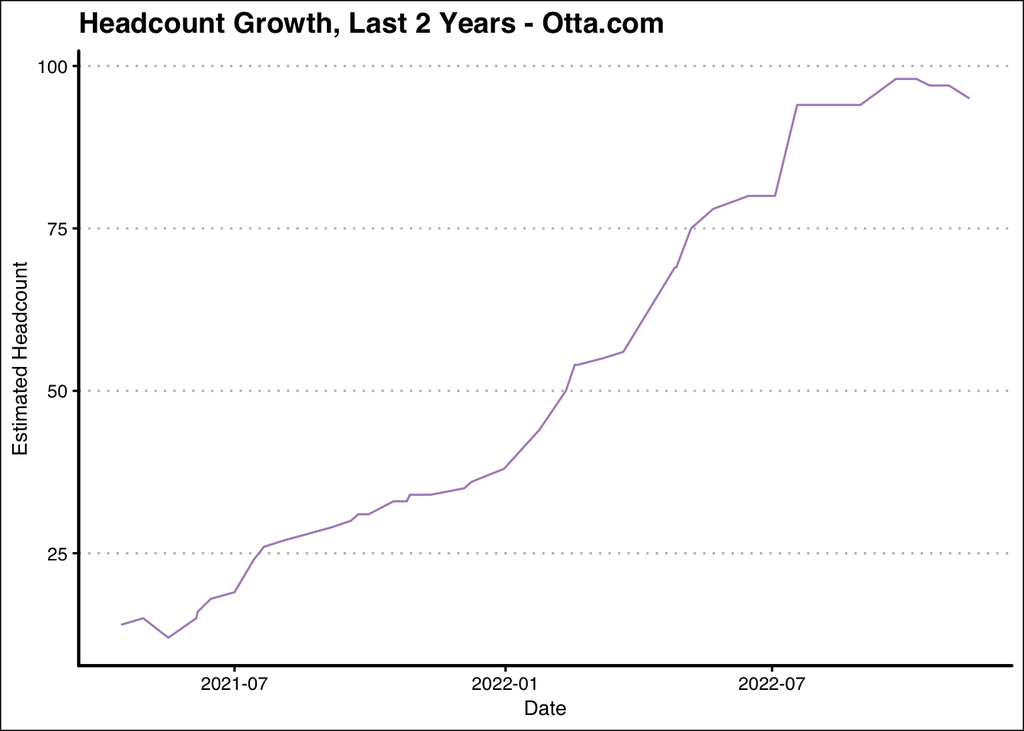

### **Traffic**

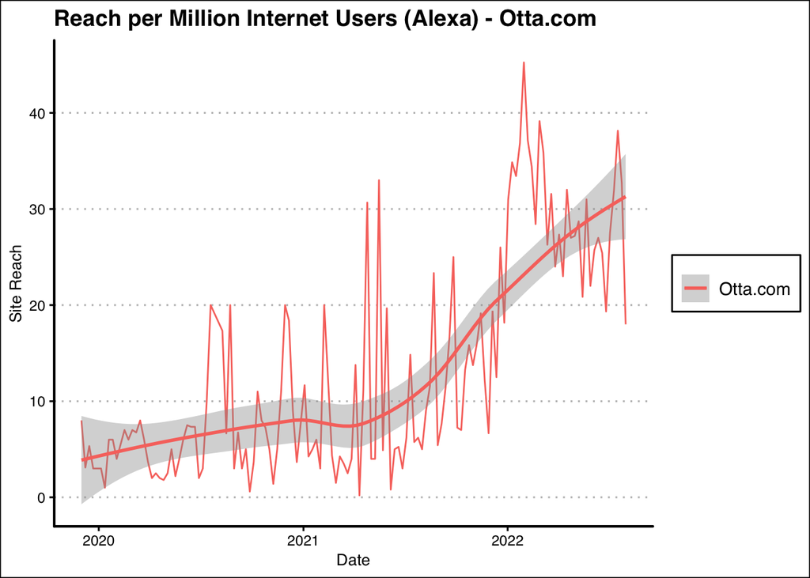

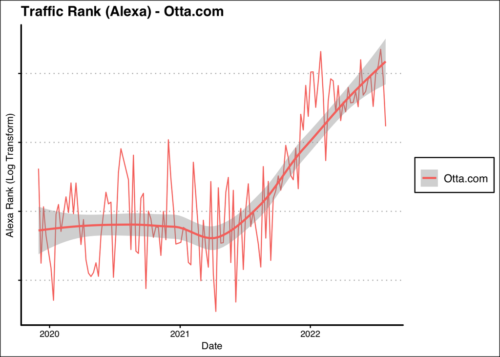

## **VEED.IO**

**Company:** VEED.IO  
**Country (Operating):** Benfleet, Essex, United Kingdom  
**Founded Date:** January 01, 2018  
**Homepage:** http://veed.io  
**Current Headcount:** 149  
**Lifetime Funding:** $35,000,000  
**Number of Funding Rounds:** 1  
**Investors:** Sequoia Capital  
**Most Recent Funding:** SERIES A - February 03, 2022  
**Sectors:** Media / News / Entertainment  
**Description:** VEED.IO is an online video editing platform that makes creating videos easy and accessible to everyone. Millions of creators around the world use our products to tell stories, create content, grow their audience and more (hey, you might even know some of them!) We’re at a super interesting stage right now: 24 months ago we had no staff and no money, and now things are going pretty well. We’re making good money, have 80+ people, and we’re one of the most popular video editors in the world. As our user base grows, so does our talented team — we’d love for you to be a part of that journey.

### **Headcount**

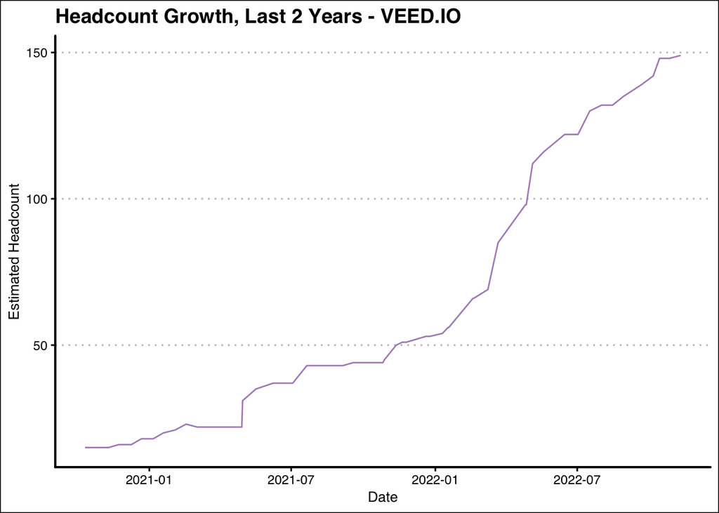

### **Traffic**

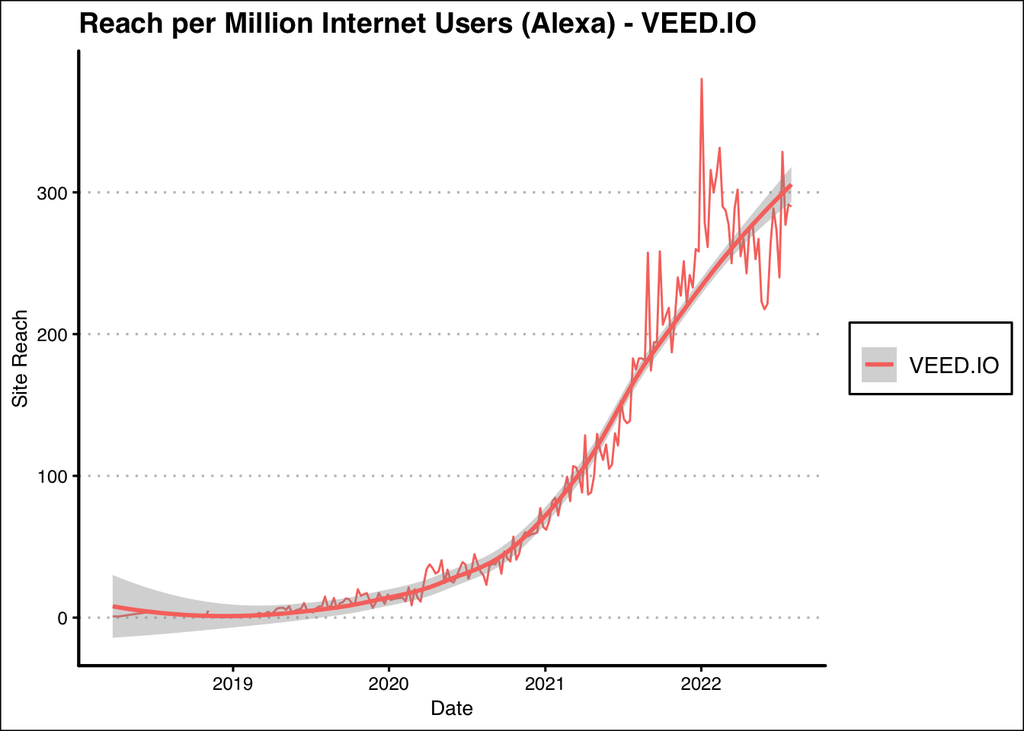

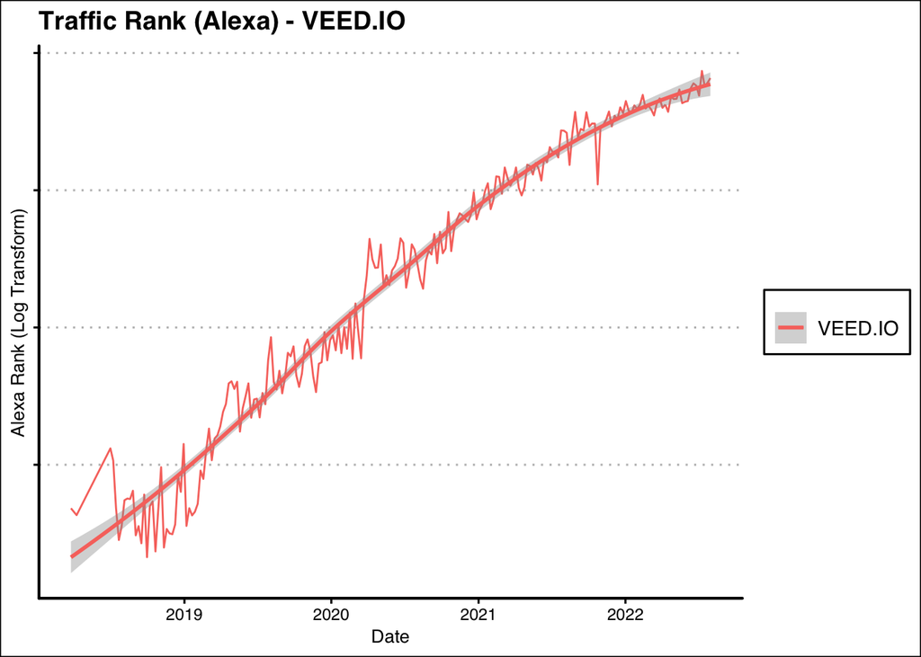

## **Mondu**

### **Headcount**

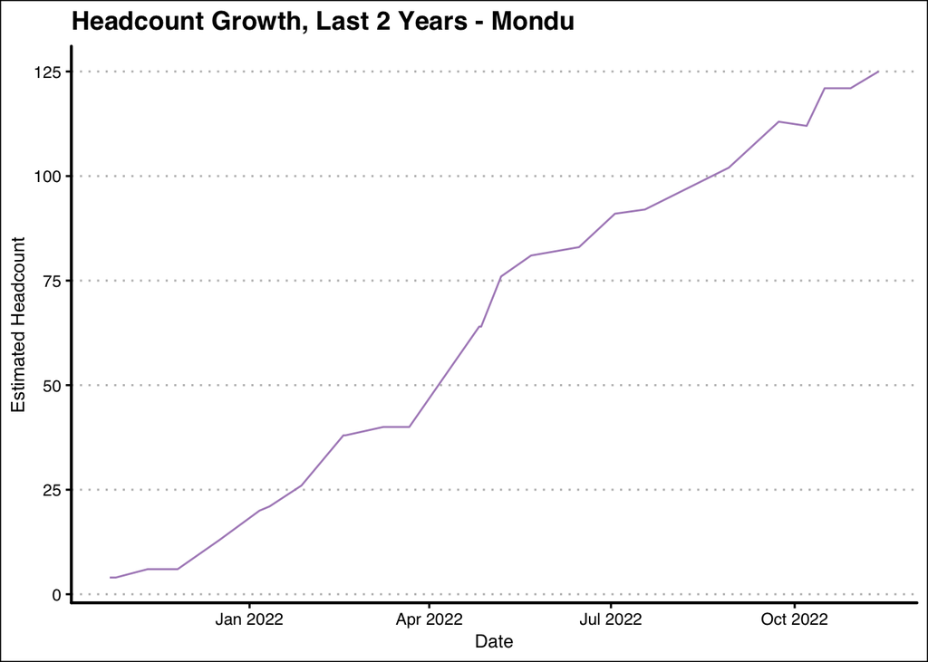

## **Upway**

**Company:** Upway  
**Country (Operating):** 231 Rue Saint Honore, 75001 Paris, France  
**Founded Date:** January 01, 2021  
**Homepage:** https://upway.shop  
**Current Headcount:** 47  
**Lifetime Funding:** $30,643,456  
**Number of Funding Rounds:** 2  
**Investors:** Henri Moissinac, Exor N.V., Sequoia Capital, EXOR Seeds, Global Founders Capital, Origins, Julien Codorniou  
**Most Recent Funding:** SERIES A - June 01, 2022  
**Sectors:** Transportation / Mobility, Automotive, Consumer Software Services  
**Description:** At Upway, we envision a world where cars are the exception and e-bikes are the norm. Our mission is to accelerate e-bike adoption and reduce waste. This is why we are building the largest marketplace for reconditioned e-bikes, making electric mobility more affordable, and giving a new life to millions of great products. We are looking for great talents to bring this mission to life!

### **Headcount**

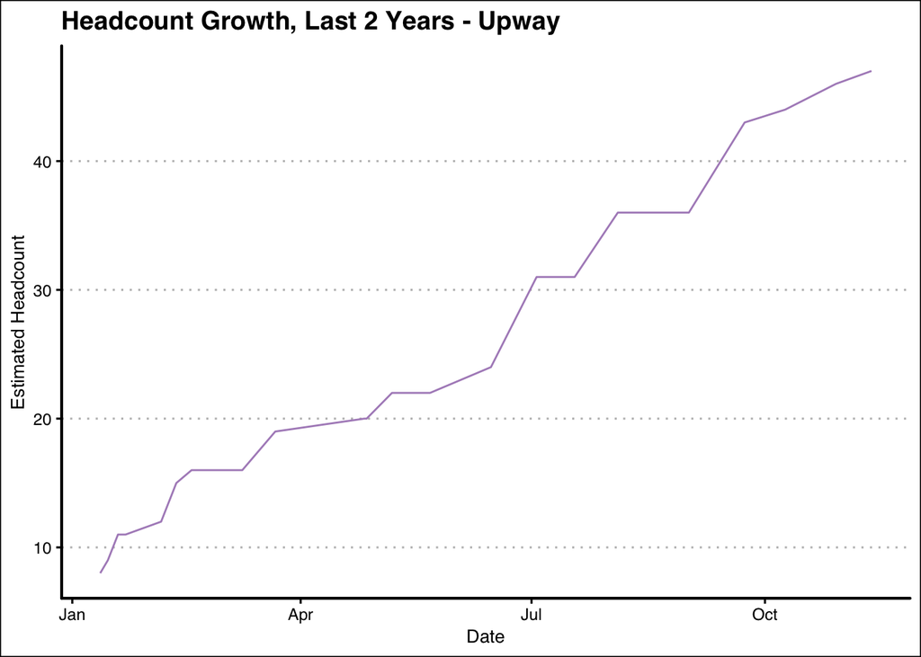

## **Z1**

### **Headcount**

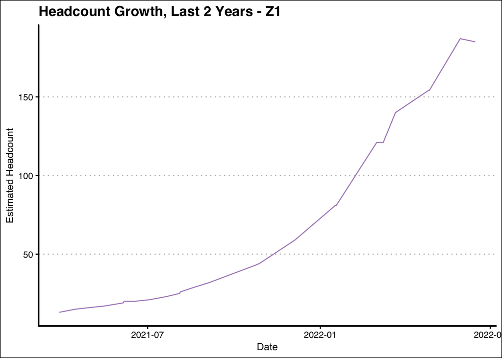

### **Traffic**

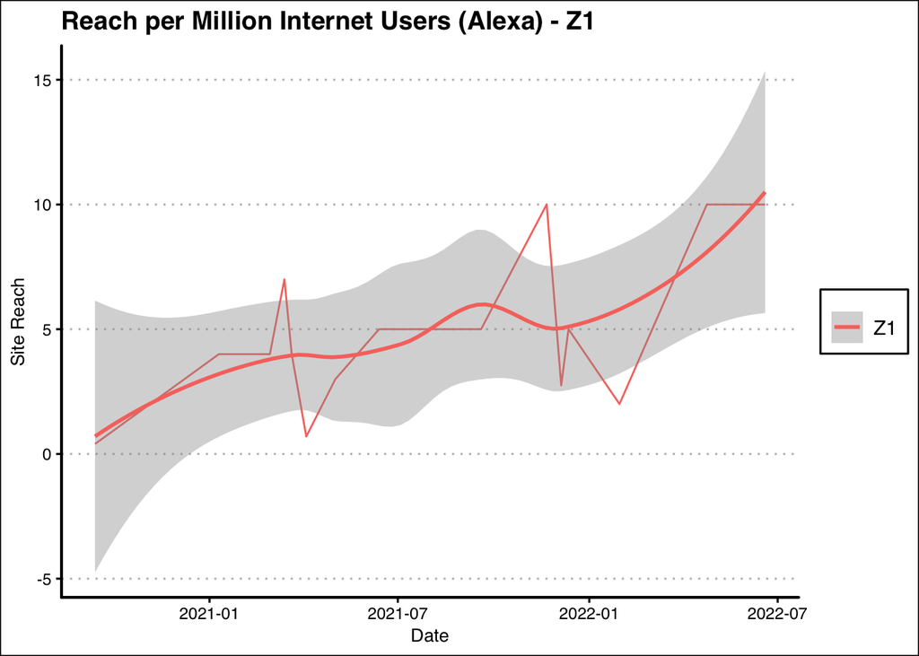

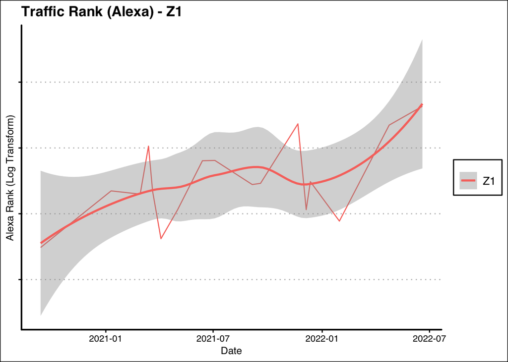

## **Chiper**

### **Headcount**

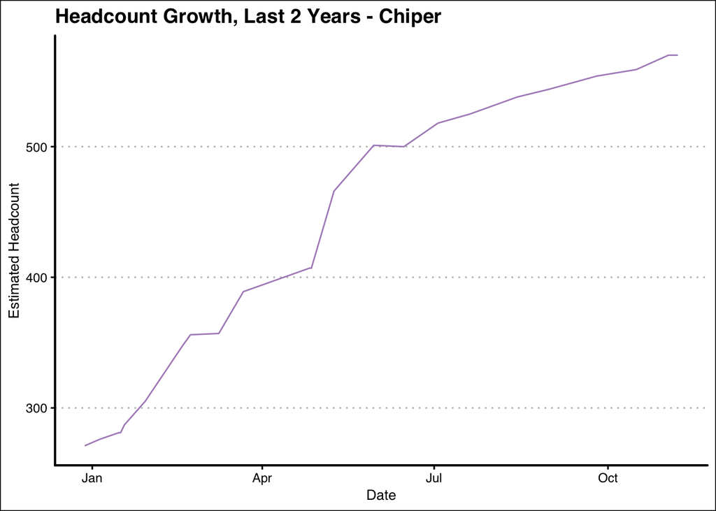

## **Telda**

**Company:** Telda  
**Country (Operating):** 11 Almaza Street, Heliopolis, Cairo Egypt  
**Founded Date:** January 01, 2021  
**Homepage:** https://telda.app  
**Current Headcount:** 45  
**Lifetime Funding:** $25,000,000  
**Number of Funding Rounds:** 2  
**Investors:** Sequoia Capital, Block, Global Founders Capital, Class 5 Global  
**Most Recent Funding:** SEED - October 12, 2022  
**Sectors:** Financial Technology, Financial / Insurance Services  
**Description:** Telda is a financial brand built for Millennials and GenZ to take the pain out of peer-to-peer payments. We are bringing a better way to send, spend and save to anyone who has ever sought an alternative to the traditional banking system.

### **Headcount**

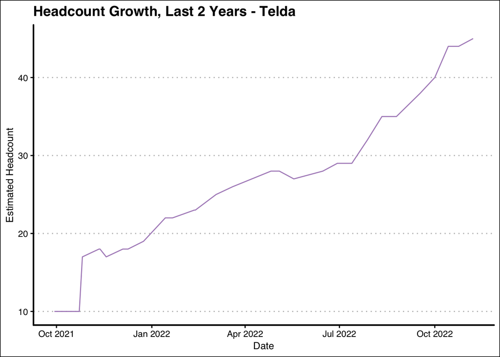

## **Azos**

**Company:** Azos  
**Country (Operating):** Avenida Brigadeiro Faria Lima, North 2.369, Jardim Paulistano, Sao Paulo, 11022-355, Brazil  
**Founded Date:** January 01, 2020  
**Homepage:** https://www.azos.com.br  
**Current Headcount:** 119  
**Lifetime Funding:** $18,267,285  
**Number of Funding Rounds:** 5  
**Investors:** Propel VC, Alter Global, MAYA CAPITAL, KASZEK, Prosus Group, Munich Re Ventures, Spectra Investments  
**Most Recent Funding:** ANGEL - June 28, 2022  
**Sectors:** Financial / Insurance Services, Financial Technology  
**Description:** We are building a leading life insurance brand for consumers in Brazil.

### **Headcount**

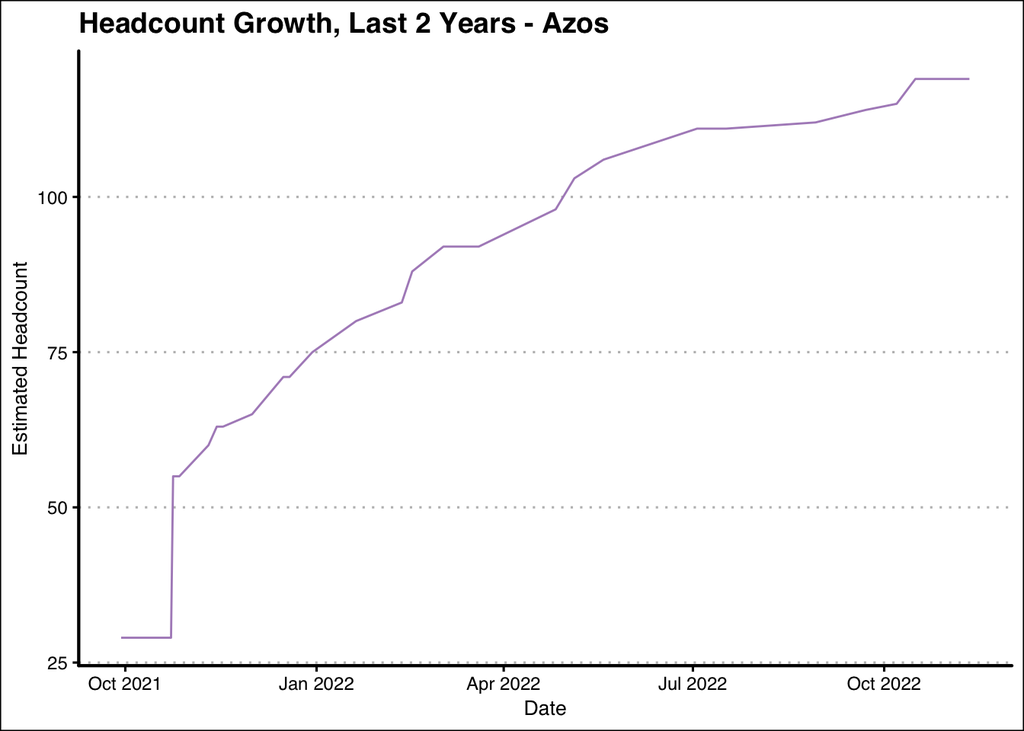

### **Traffic**

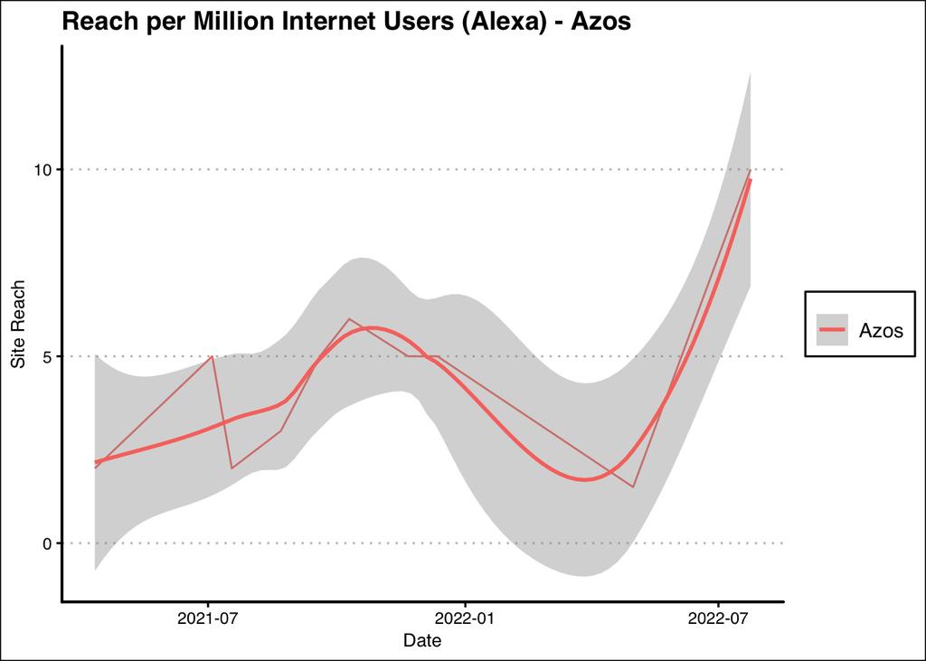

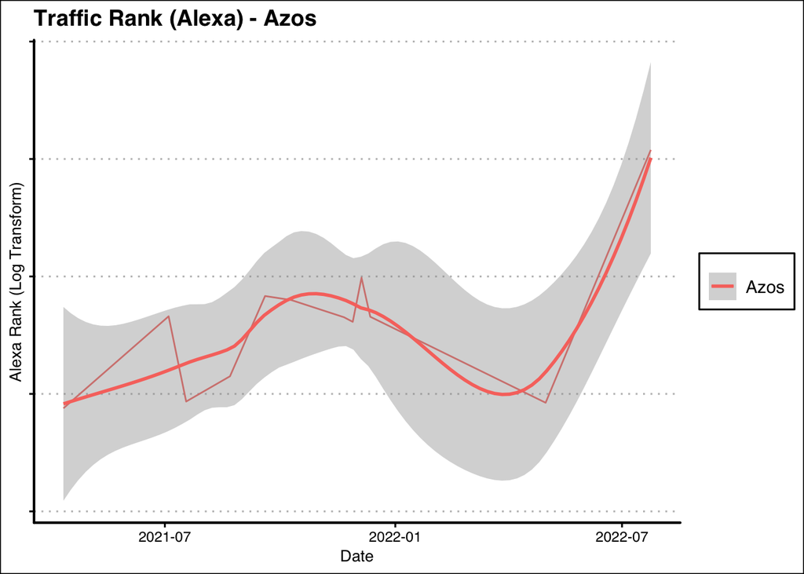

## **AI21 Labs**

**Company:** AI21 Labs  
**Country (Operating):** Shlomo Ibn Gabirol Street 124, Tel Aviv 6203854, Israel  
**Founded Date:** January 01, 2017  
**Homepage:** https://www.ai21.com  
**Current Headcount:** 128  
**Lifetime Funding:** $118,500,000  
**Number of Funding Rounds:** 4  
**Investors:** Al Borg Diagnostics, Ahren Innovation Capital, Pitango, TPY Capital, Amnon Shashua, Mark Leslie, 8VC, Walden Catalyst Ventures  
**Most Recent Funding:** SERIES B - July 12, 2022  
**Sectors:** AI / ML, Consumer Software Services  
**Description:** Bringing AI into the 21st century.

### **Headcount**

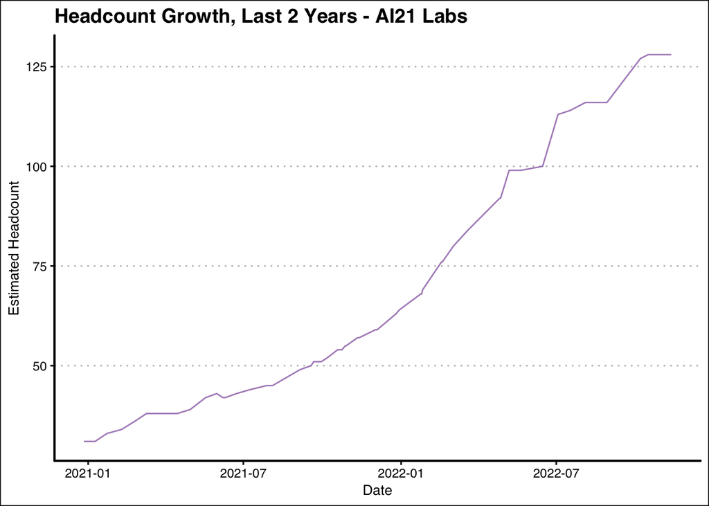

## **Tailscale**

**Company:** Tailscale  
**Country (Operating):** 125-720 King Street West, Suite 585, Toronto, Ontario M5V 3S5, Canada  
**Founded Date:** January 01, 2019  
**Homepage:** https://tailscale.com  
**Current Headcount:** 61  
**Lifetime Funding:** $115,000,000  
**Number of Funding Rounds:** 4  
**Investors:** Inovia Capital, TenOneTen Ventures, Insight Partners, Heavybit, Cyber Mentor Fund, Accel, Zag Capital, Uncork Capital, CRV, 10X Capital, Emilio E., Stephanie Friedman, Edith Harbaugh  
**Most Recent Funding:** SERIES B - May 12, 2022  
**Sectors:** Security / Encryption Tech, Cybersecurity  
**Description:** For teams who want secure, private networks without weeks of setup and configuration, Tailscale makes it easy. Unlike existing corporate VPNs, Tailscale has no upfront cost, minimal latency, and works with their existing services.

### **Headcount**

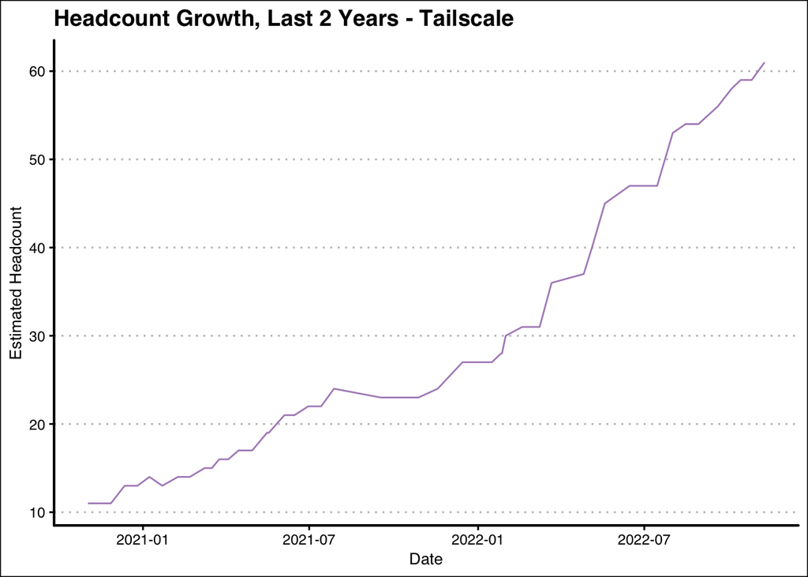

### **Traffic**

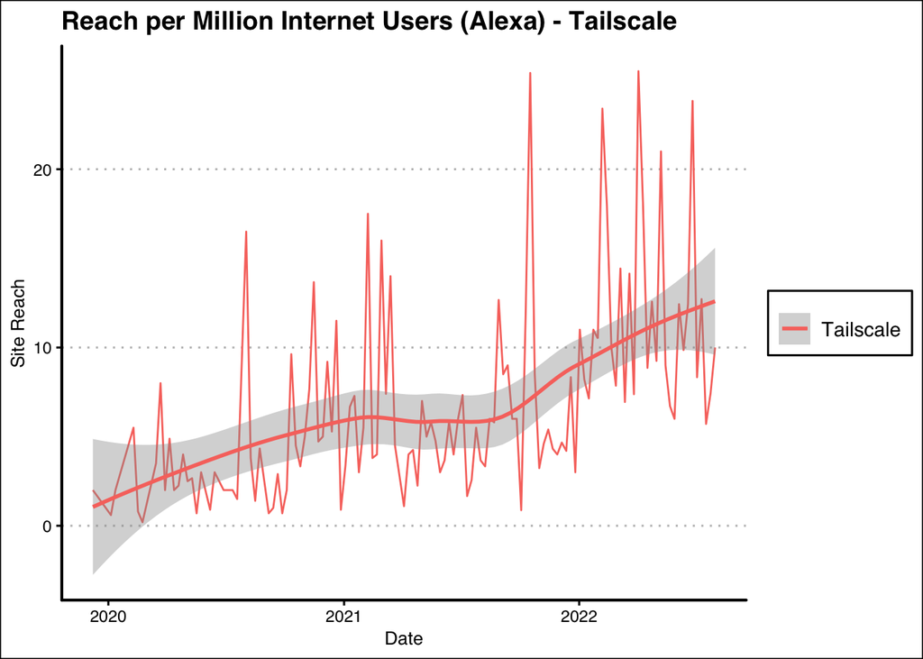

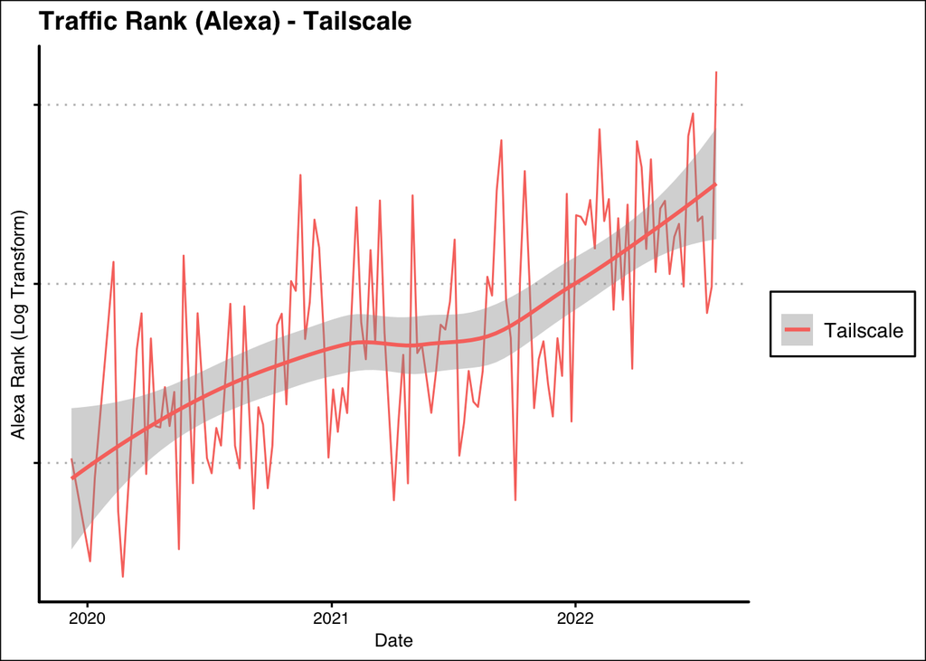